# EI-EP05-respuesta-equipo-1

2025-09-24

## **Contexto**

En una emocionante competencia de cubos Rubik, participantes de Chile, Argentina, Colombia, Uruguay, Perú y Ecuador demostraron su destreza en resolver tres tipos de cubos: 2x2x2, 3x3x3 y Megaminx.

Después del torneo, un grupo de investigadores de la Asociación Mundial del Cubo, interesado en los tiempos que hicieron las jugadoras y los jugadores en la competencia, decidieron estudiar si el país y el tipo de cubo usado en cada prueba tienen influencia en los segundos que se tardan en resolverlos. Para ello usaron una muestra aleatoria de los datos de la competencia, en la cual participaron más de 2.000 personas, con las siguientes variables:

- **id**: Identificador único de cada participante.
- **pais**: País que representa cada participante (Argentina, Chile, Colombia, Ecuador, Perú, Uruguay).
- **tipo**: Tipo de cubo usado en la prueba (2x2x2, 3x3x3, Megaminx).
- **tiempo**: Tiempo, en segundos, que toma al participante en resolver el cubo de la prueba.

## **Problema**

¿Existen diferencias en el tiempo de resolución de cubos 2x2x2 entre participantes de Chile, Perú y Argentina?

```r
#primero cargaremos los datos
data <- read.csv2("EP05 Datos.csv")
head(data)
```

```
##   X id  pais     tipo tiempo
## 1 1 17  Perú    2x2x2   4.89
## 2 2 17  Perú    3x3x3  17.00
## 3 3 17  Perú Megaminx  75.57
## 4 4 31 Chile    2x2x2   5.12
## 5 5 31 Chile    3x3x3  15.30
## 6 6 31 Chile Megaminx  75.30
```

```r
# Filtrar datos por pais y tipo

data_filter_chile <- data |>
  filter(tipo=="2x2x2",pais=="Chile" )
data_filter_arg <- data |>
  filter(tipo=="2x2x2",pais=="Argentina" )
data_filter_peru <- data |>
  filter(tipo=="2x2x2",pais=="Perú" )
data_filter_chile <- head(data_filter_chile, n = 38)
data_filter_peru <- head(data_filter_peru, n = 38)
data_filter <- rbind(data_filter_chile,data_filter_arg,data_filter_peru)


head(data_filter)
```

```
##    X  id  pais  tipo tiempo
## 1  4  31 Chile 2x2x2   5.12
## 2 49 145 Chile 2x2x2   5.15
## 3 61 175 Chile 2x2x2   5.16
## 4 73 211 Chile 2x2x2   5.20
## 5 79 217 Chile 2x2x2   4.97
## 6 82 235 Chile 2x2x2   5.16
```

```r
tail(data_filter)
```

```
##       X   id pais  tipo tiempo
## 109 565 1625 Perú 2x2x2   4.88
## 110 574 1649 Perú 2x2x2   4.93
## 111 625 1805 Perú 2x2x2   4.78
## 112 631 1811 Perú 2x2x2   4.79
## 113 637 1835 Perú 2x2x2   4.99
## 114 640 1847 Perú 2x2x2   4.93
```

Para Responder a la pregunta propuesta estableceremos las hipótesis a constrastar

- $H_0$: La diferencia de medias entre los tiempos de resolución de cubos de rubic de 2x2x2 entre participantes de chile, peru y argentina es igual
- $H_a$: La diferencia de medias entre los tiempos de resolución de cubos de rubic de 2x2x2 entre participantes de chile, peru y argentina es distinta de cero

Establecidas estas hipótesis a contratar, procedemos a verificar las condiciones para llevar a cabo la prueba

1. La escala con la que se medie la variable dependiente tiene las propiedades de una escala de intervalos iguales, en este caso esta condición se cumple ya que la escala de medición son los segundos la cual es una escala de intervalos iguales
2. Las k muestras son obtenidas de manera aleatoria e independiente desde la(s) población(es) de origen, en este caso basandonos en el enunciado podemos ver que las muetras fueron tomadas aleatoriamente, por lo que cumple
3. Para verificar si las poblaciones siguen una distribución normal, entonces ocuparemos los graficos qqplot para graficar las 3 instancias

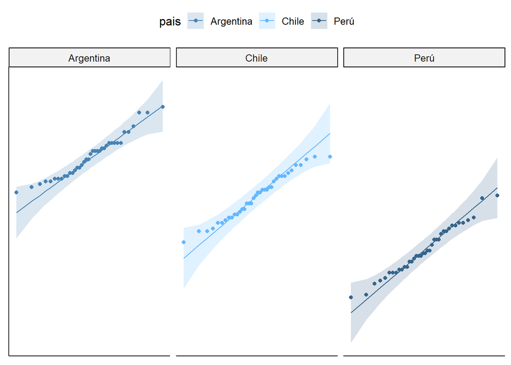

```r
g1 <- ggqqplot(data_filter, x="tiempo", y="pais",color="pais",alpha=0.7,
               palette=c("steelblue","steelblue1","steelblue4"))

g1 <- g1 + facet_wrap(~ pais)
g1 <- g1 + rremove("x.ticks") + rremove("x.text")
g1 <- g1 + rremove("y.ticks") + rremove("y.text")
g1 <- g1 + rremove("axis.title")
print(g1)
```

Por lo tanto, concluimos que los datos siguen una distribución normal.

4. las varainzas deben ser iguales: para esto correremos la prueba ezANOVA asumiendo que se cumple ya que la misma prueba corre un test para la homocedasticidad, pero antes pasaremos a factor las varaibles involucradas

```r
data_filter$id <- as.factor(data_filter$id)
data_filter$pais <- as.factor(data_filter$pais)
```

```r
prueba <- ezANOVA(data_filter,dv=tiempo,between = pais,wid = id, return_aov = TRUE)
```

```
## Coefficient covariances computed by hccm()
```

```r
print(prueba)
```

```
## $ANOVA
##   Effect DFn DFd        F            p p<.05       ges
## 1   pais   2 111 155.5951 6.305598e-33     * 0.7370853
##
## $`Levene's Test for Homogeneity of Variance`
##   DFn DFd         SSn       SSd        F         p p<.05
## 1   2 111 0.001247368 0.2469763 0.280306 0.7560857
##
## $aov
## Call:
##    aov(formula = formula(aov_formula), data = data)
##
## Terms:
##                      pais Residuals
## Sum of Squares  2.1922158 0.7819526
## Deg. of Freedom         2       111
##
## Residual standard error: 0.08393222
## Estimated effects may be unbalanced
```

```r
g2<- ezPlot(data=data_filter, dv=tiempo, wid=id, between = pais, y_lab = "Tiempo promedio de resolución [s]", x = pais)
```

```
## Coefficient covariances computed by hccm()
```

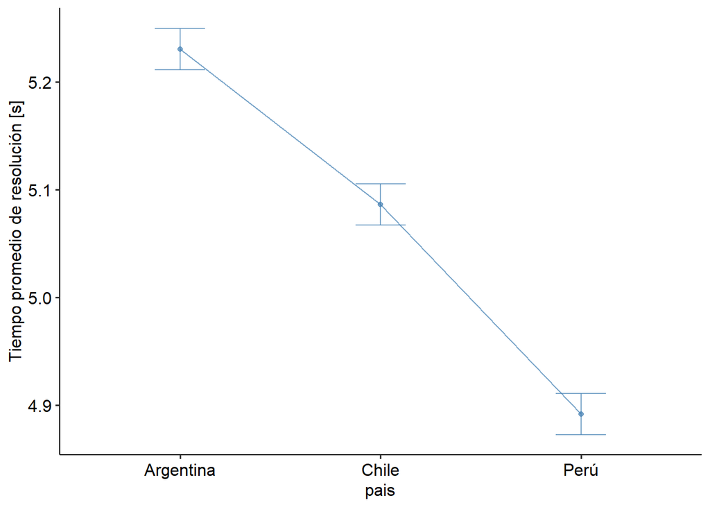

```r
g2<- g2 + theme_pubr()
g2[["layers"]][[1]][["aes_params"]] <- list(colour = "steelblue", alpha=0.7) # lineas
g2[["layers"]][[2]][["aes_params"]] <- list(colour = "steelblue", alpha=0.7) # puntos
g2[["layers"]][[3]][["aes_params"]] <- list(colour = "steelblue", alpha=0.7) # error
print(g2)
```

Con esto podemos primero confirmar que los datos son homocedasticos ya que la hipotesis de la prueba de levene’s para homogeneidad de varianzas es que las varianzas si son homogeneas, por lo que con un p value de 0.75 podemos corroborar la condicion nro 4, por otro lado podemos fijarnos que la prueba nos arroja un p value de 6.305598e-33 con lo cual no nos queda mas que recahzar la hipotesis nula a favor de la hipotesis alternativa.

Una vez hecho este analisis para averiguar cual es la media que tiene diferencia, aplicaremos una prueba post-hoc en este caso una pairwise.t.test

```r
bh <- pairwise.t.test(data_filter[["tiempo"]], data_filter[["pais"]], p.adj="fdr",pool.sd = TRUE, paired = FALSE,conf.level=1-0.05)
print(bh)
```

```
##
##  Pairwise comparisons using t tests with pooled SD
##
## data:  data_filter[["tiempo"]] and data_filter[["pais"]]
##
##       Argentina Chile
## Chile 1.9e-11   -
## Perú  < 2e-16   < 2e-16
##
## P value adjustment method: fdr
```

Hecha esta prueba podemos ver que chile y argentina con un p value de 1.9e-11 tienen medias distintas, peru y chile con un p value de 2e-16 tienen medias diferentes y paru con chile tienen una diferencia de medias con un pvalue de 2e-16, por lo que concluimos que todas las medias son diferentes por lo tanto concluimos que si existen diferencias entre los tiempos de resolcuión de cubos 2x2x2 entre los participantes de chile, peru y argentina.